# KOI analysis - Model using PCA

Davide Tonetto

19 May, 2025

# 1 Load data

Load the cleaned data from **`data_preparation.rmd`**.

```r
koi_data <- readRDS("data/Rdas/koi_data.Rda")
```

Drop missing values for the interested columns.

```r
koi_data <- koi_data %>%
  drop_na(
    koi_period, koi_duration, koi_depth, koi_prad, koi_teq,
    koi_insol, koi_model_snr, koi_steff, koi_slogg, koi_srad,
    koi_smass, koi_impact, koi_ror, koi_srho, koi_sma, koi_incl,
    koi_dor, koi_ldm_coeff1, koi_ldm_coeff2, koi_smet
  )
```

## 1.1 Split data in training and test sets

```r
# Split data into training and test sets with stratification
set.seed(42)
train_indices <- createDataPartition(koi_data$koi_pdisposition, p = 0.8, list = FALSE)
train_data <- koi_data[train_indices, ]
test_data <- koi_data[-train_indices, ]
```

Separate features and target.

```r
target_variable_name <- "koi_pdisposition"
predictor_variable_names <- koi_data %>%
  select(
    koi_period, koi_duration, koi_depth, koi_prad, koi_teq,
    koi_insol, koi_model_snr, koi_steff, koi_slogg, koi_srad,
    koi_smass, koi_impact, koi_ror, koi_srho, koi_sma, koi_incl,
    koi_dor, koi_ldm_coeff1, koi_ldm_coeff2, koi_smet
  ) %>%
  names()

train_predictors <- train_data[, predictor_variable_names]
train_target <- train_data[[target_variable_name]]

test_predictors <- test_data[, predictor_variable_names]
test_target <- test_data[[target_variable_name]]
```

# 2 PCA analysis

## 2.1 Train PCA model

Train the PCA model on the training data.

```r
train_predictors <- scale(train_predictors)
pca_fit_train <- prcomp(train_predictors, center = FALSE, scale. = FALSE)
```

## 2.2 Transform Data using PCA Fit

Transform the training and test data using the PCA fit.

```r
train_pcs <- as.data.frame(predict(pca_fit_train, newdata = train_predictors))
test_pcs <- as.data.frame(predict(pca_fit_train, newdata = test_predictors))
```

## 2.3 Select Number of Principal Components (PCs)

From **`data_visualization.rmd`**, we know that the first 11 PCs explain 90% of the variance.

```r
num_pcs_to_keep <- 11
train_pcs_selected <- train_pcs[, 1:num_pcs_to_keep]
test_pcs_selected <- test_pcs[, 1:num_pcs_to_keep]
```

Final dataset for modelling:

```r
train_data_final <- cbind(train_pcs_selected, target = train_target)
test_data_final <- cbind(test_pcs_selected, target = test_target)

# Convert factor levels to R-friendly names
train_data_final$target <- factor(train_data_final$target,
  levels = c("CANDIDATE", "FALSE POSITIVE"),
  labels = c("candidate", "false_positive")
)
test_data_final$target <- factor(test_data_final$target,
  levels = c("CANDIDATE", "FALSE POSITIVE"),
  labels = c("candidate", "false_positive")
)

# names(train_data_final)[names(train_data_final) == "koi_pdisposition"] <- target_variable_name
# names(test_data_final)[names(test_data_final) == "koi_pdisposition"] <- target_variable_name
```

# 3 Models

## 3.1 Random Forest

Let’s train a Random Forest model using the PCA-transformed data.

```r
# Define training control (e.g., cross-validation)
train_control <- trainControl(method = "cv", number = 10, classProbs = TRUE, summaryFunction = twoClassSummary) # Example for binary classification

# Train a model (e.g., Random Forest)
model_rf_pca <- train(target ~ ., # Formula using target and all PCs in the data frame
  data = train_data_final,
  method = "rf", # Random Forest
  trControl = train_control,
  metric = "ROC"
) # Optimize for AUC

# Print model summary
print(model_rf_pca)
```

```
## Random Forest
##
## 6347 samples
##   11 predictor
##    2 classes: 'candidate', 'false_positive'
##
## No pre-processing
## Resampling: Cross-Validated (10 fold)
## Summary of sample sizes: 5713, 5711, 5711, 5713, 5713, 5713, ...
## Resampling results across tuning parameters:
##
##   mtry  ROC        Sens       Spec
##    2    0.8586057  0.7988693  0.7657604
##    6    0.8580269  0.8057035  0.7644835
##   11    0.8542829  0.8066313  0.7539107
##
## ROC was used to select the optimal model using the largest value.
## The final value used for the model was mtry = 2.
```

```r
# Make predictions on the test set
predictions <- predict(model_rf_pca, newdata = test_data_final)
prob_predictions <- predict(model_rf_pca, newdata = test_data_final, type = "prob")
```

### 3.1.1 Model performance

The following table shows the confusion matrix for the Random Forest model.

```r
cm_rf <- confusionMatrix(predictions, test_data_final$target)
cm_rf
```

```
## Confusion Matrix and Statistics
##
##                 Reference
## Prediction       candidate false_positive
##   candidate            736            523
##   false_positive        69            258
##
##                Accuracy : 0.6267
##                  95% CI : (0.6024, 0.6506)
##     No Information Rate : 0.5076
##     P-Value [Acc > NIR] : < 2.2e-16
##
##                   Kappa : 0.2468
##
##  Mcnemar's Test P-Value : < 2.2e-16
##
##             Sensitivity : 0.9143
##             Specificity : 0.3303
##          Pos Pred Value : 0.5846
##          Neg Pred Value : 0.7890
##              Prevalence : 0.5076
##          Detection Rate : 0.4641
##    Detection Prevalence : 0.7938
##       Balanced Accuracy : 0.6223
##
##        'Positive' Class : candidate
##
```

Let’s plot the confusion matrix.

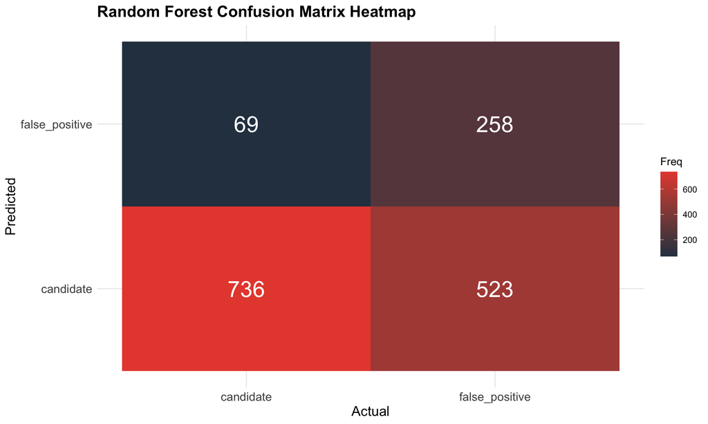

```r
cm_data <- as.data.frame(cm_rf$table)

# Create heatmap
ggplot(cm_data, aes(x = Reference, y = Prediction, fill = Freq)) +
  geom_tile() +
  geom_text(aes(label = Freq), color = "white", size = 8) +
  scale_fill_gradient(low = "#2C3E50", high = "#E74C3C") +
  theme_minimal() +
  labs(
    title = "Random Forest Confusion Matrix Heatmap",
    x = "Actual",
    y = "Predicted"
  ) +
  theme(
    axis.text = element_text(size = 12),
    axis.title = element_text(size = 14),
    plot.title = element_text(size = 16, face = "bold")
  )
```

Now the ROC curve.

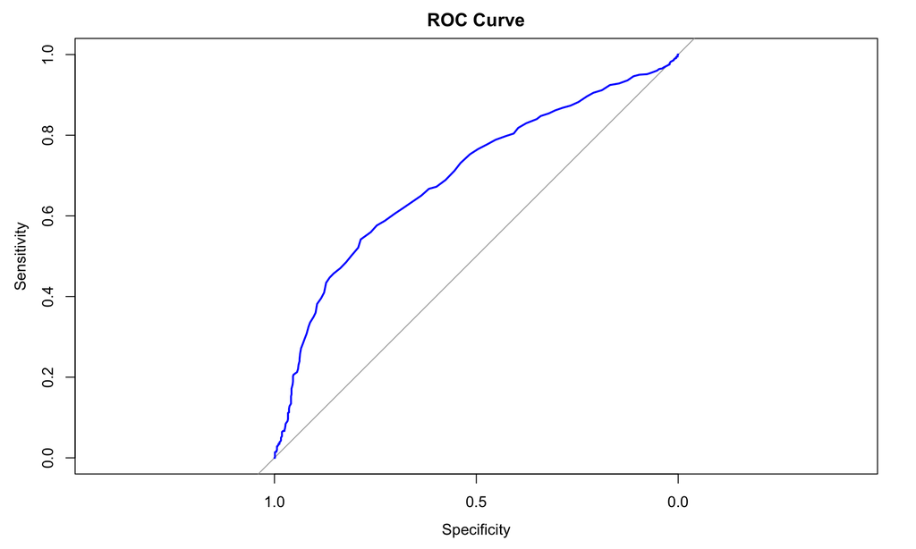

```r
# Create ROC curve
roc_curve_rf <- roc(test_data_final$target, prob_predictions[, "candidate"])
# Plot ROC curve
plot(roc_curve_rf, main = "ROC Curve", col = "blue", lwd = 2)
```

### 3.1.2 Summary

The model built with PCA features is significantly better than random guessing but shows only “fair” predictive power overall (Kappa ~0.25).

- Strength: It excels at finding true candidates (High Sensitivity).
- Weakness: It performs poorly at identifying false_positives, incorrectly labeling many of them as candidates (Low Specificity, leading to many False Positives).

In conclusion, while it captures most real candidates, predictions of candidates have relatively low confidence (Low Precision), whereas predictions of false_positive are more reliable (Higher Negative Predictive Value). Implications:

If the goal is discovery (finding as many potential candidates as possible for follow-up, even if many are false alarms), this model might be useful due to its high sensitivity. If the goal is high confidence classification (being sure that predicted candidates are indeed candidates), this model is less suitable due to its low precision.

## 3.2 Logistic Regression

Let’s train a Logistic Regression model using the PCA-transformed data.

```r
glm_model_pca <- glm(target ~ .,
  data = train_data_final,
  family = binomial(link = "logit")
)

summary(glm_model_pca)
```

```
##
## Call:
## glm(formula = target ~ ., family = binomial(link = "logit"),
##     data = train_data_final)
##
## Coefficients:
##             Estimate Std. Error z value Pr(>|z|)
## (Intercept)  -5.0551     2.8570  -1.769 0.076834 .
## PC1          -9.3741     0.6834 -13.717  < 2e-16 ***
## PC2           5.6600     0.3024  18.714  < 2e-16 ***
## PC3           4.8335     0.4855   9.957  < 2e-16 ***
## PC4          13.4321     0.9577  14.026  < 2e-16 ***
## PC5          -1.6377     1.3766  -1.190 0.234186
## PC6          -1.2367     0.4511  -2.741 0.006119 **
## PC7           0.3557     0.4394   0.809 0.418288
## PC8          -3.7584     0.6578  -5.714 1.11e-08 ***
## PC9           2.4922     0.6681   3.730 0.000191 ***
## PC10          5.9389     0.5151  11.529  < 2e-16 ***
## PC11        -19.9502     2.1664  -9.209  < 2e-16 ***
## ---
## Signif. codes:  0 '***' 0.001 '**' 0.01 '*' 0.05 '.' 0.1 ' ' 1
##
## (Dispersion parameter for binomial family taken to be 1)
##
##     Null deviance: 8797.3  on 6346  degrees of freedom
## Residual deviance: 6101.6  on 6335  degrees of freedom
## AIC: 6125.6
##
## Number of Fisher Scoring iterations: 7
```

1. Coefficients & Significance (Pr(>|z|)): Most of the principal components included (PC1, PC2, PC3, PC4, PC6, PC8, PC9, PC10, PC11) have very small p-values (< 2e-16, ***,** ). This indicates they have a statistically significant relationship with the log-odds of the target variable (likely ‘candidate’ vs ‘false_positive’) after accounting for the other PCs in the model. PC5 and PC7 are not statistically significant in this model (p-values 0.23 and 0.42). This suggests that, given the other PCs, they don’t add significant predictive power in this specific linear combination. The Estimate column shows the direction and magnitude of the effect on the log-odds. For example, PC1 has a large negative coefficient (-9.37), meaning an increase in PC1 strongly decreases the log-odds of the positive class. PC4 has a large positive coefficient (13.43), strongly increasing the log-odds. PC11 has a very large negative coefficient (-19.95).
2. Model Fit (Deviance & AIC): The drop from Null deviance (8797.3) to Residual deviance (6101.6) shows that the model including the PCs explains a significant amount of the variation compared to a model with just an intercept. AIC (6125.6) is an information criterion useful for comparing different models (lower is generally better), but less interpretable on its own. In short, the summary shows that most of the first 11 PCs are statistically useful predictors within the logistic regression framework.

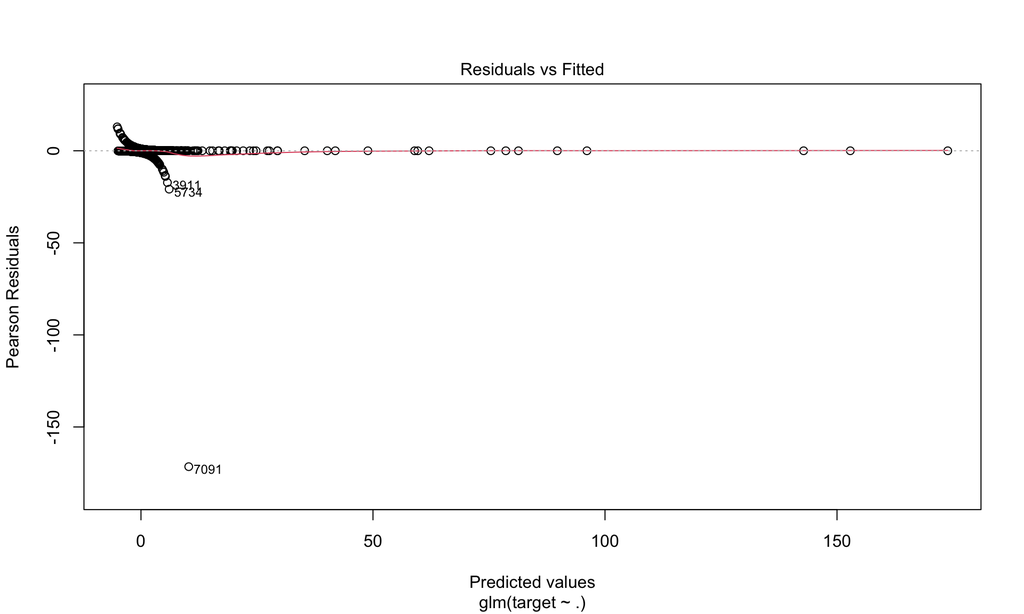

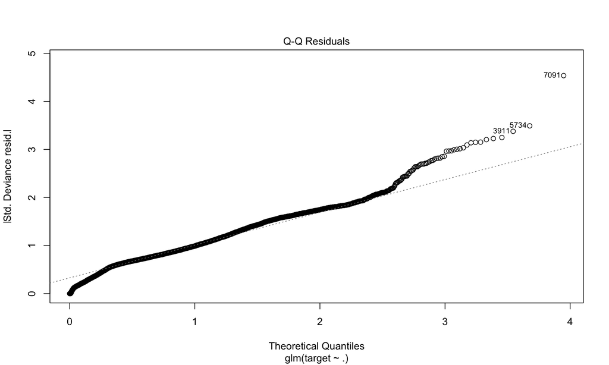

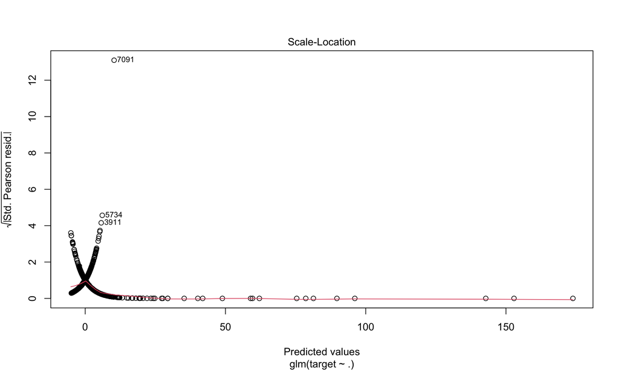

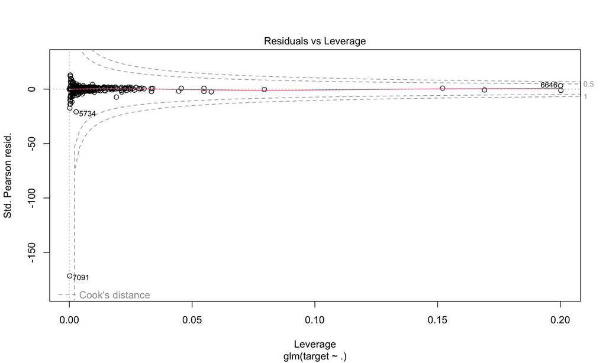

```r
plot(glm_model_pca)
```

### 3.2.1 Model performance

Now test the model on the test set.

```r
predicted_probabilities <- predict(glm_model_pca, newdata = test_data_final, type = "response")

# Convert predicted probabilities to binary predictions
threshold <- 0.5
# Identify the positive class level (usually the second level)
positive_class <- levels(train_data_final$target)[2]
negative_class <- levels(train_data_final$target)[1]

predicted_classes <- ifelse(predicted_probabilities > threshold, positive_class, negative_class)
# Convert character predictions back to a factor with the same levels as the original target
predicted_classes <- factor(predicted_classes, levels = levels(test_data_final$target))


# Create a confusion matrix
cm_glm_pca <- confusionMatrix(
  data = predicted_classes,
  reference = test_data_final$target,
  positive = positive_class
)
cm_glm_pca
```

```
## Confusion Matrix and Statistics
##
##                 Reference
## Prediction       candidate false_positive
##   candidate            788            419
##   false_positive        17            362
##
##                Accuracy : 0.7251
##                  95% CI : (0.7024, 0.7469)
##     No Information Rate : 0.5076
##     P-Value [Acc > NIR] : < 2.2e-16
##
##                   Kappa : 0.4458
##
##  Mcnemar's Test P-Value : < 2.2e-16
##
##             Sensitivity : 0.4635
##             Specificity : 0.9789
##          Pos Pred Value : 0.9551
##          Neg Pred Value : 0.6529
##              Prevalence : 0.4924
##          Detection Rate : 0.2282
##    Detection Prevalence : 0.2390
##       Balanced Accuracy : 0.7212
##
##        'Positive' Class : false_positive
##
```

Let’s plot the confusion matrix.

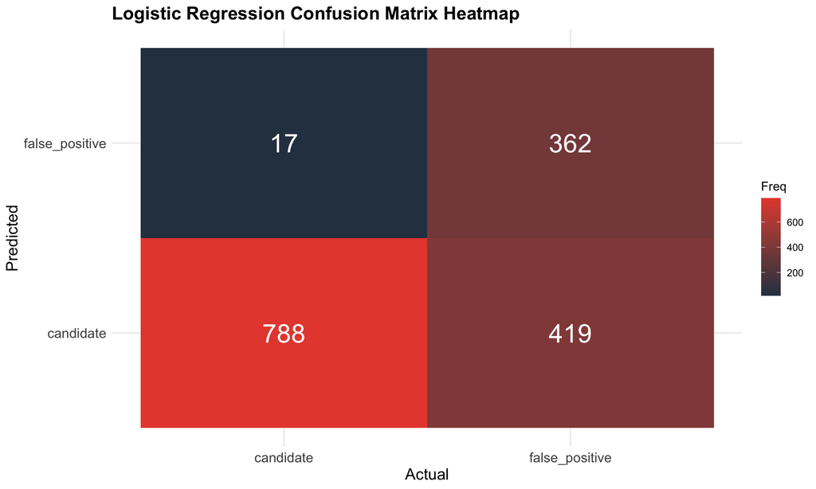

```r
cm_data <- as.data.frame(cm_glm_pca$table)

# Create heatmap
ggplot(cm_data, aes(x = Reference, y = Prediction, fill = Freq)) +
  geom_tile() +
  geom_text(aes(label = Freq), color = "white", size = 8) +
  scale_fill_gradient(low = "#2C3E50", high = "#E74C3C") +
  theme_minimal() +
  labs(
    title = "Logistic Regression Confusion Matrix Heatmap",
    x = "Actual",
    y = "Predicted"
  ) +
  theme(
    axis.text = element_text(size = 12),
    axis.title = element_text(size = 14),
    plot.title = element_text(size = 16, face = "bold")
  )
```

Now the ROC curve.

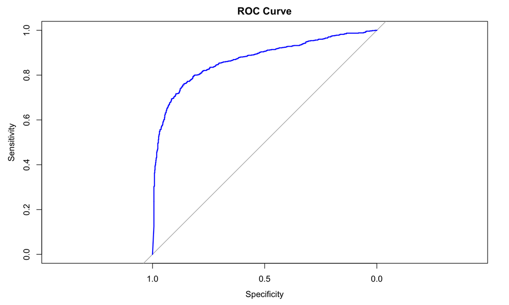

```r
# Create ROC curve
roc_curve_glm <- roc(test_data_final$target, predicted_probabilities)
# Plot ROC curve
plot(roc_curve_glm, main = "ROC Curve", col = "blue", lwd = 2)
```

### 3.2.2 Summary

The logistic regression model using the first 11 principal components shows that most of these components are statistically significant predictors of the outcome (p < 0.05). When evaluating this model with ‘false_positive’ defined as the positive class, it achieves an overall accuracy of about 73% and moderate agreement (Kappa ≈ 0.45). Its main strength is correctly identifying true candidates (Specificity ≈ 98%) and having high confidence when it predicts ‘false_positive’ (Precision ≈ 96%). However, its major weakness is missing many actual false positives (Sensitivity ≈ 46%). This performance profile, emphasizing high specificity over sensitivity, is the inverse of what was seen when ‘candidate’ was the positive class, indicating a model that is generally hesitant to label something as a ‘false_positive’ unless it’s very confident.

### 3.2.3 Residual analysis.

Plot residuals against each continuous predictor in the model.

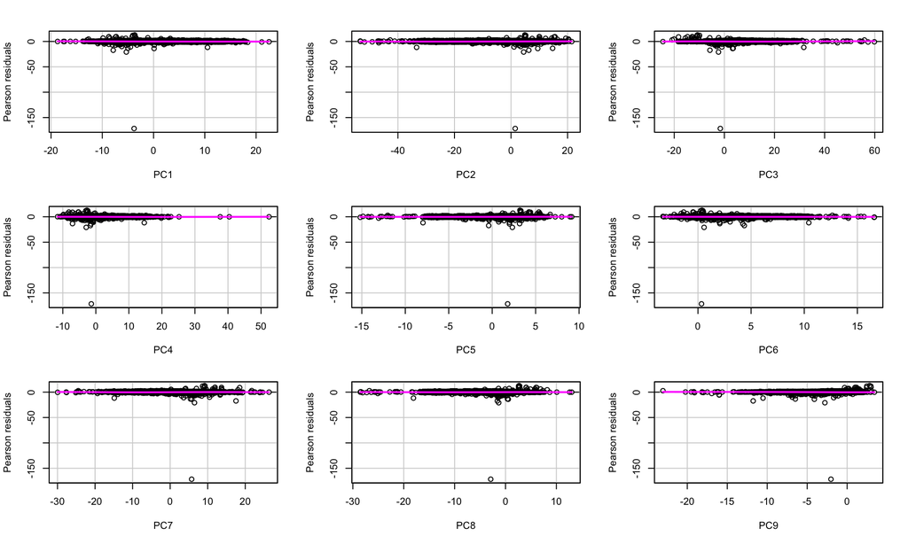

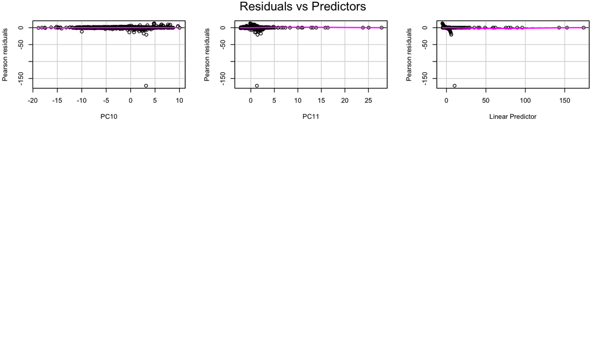

```
##      Test stat Pr(>|Test stat|)
## PC1     2.8238        0.0928777 .
## PC2     1.1903        0.2752761
## PC3    42.1569        8.423e-11 ***
## PC4    13.5804        0.0002286 ***
## PC5     1.0208        0.3123374
## PC6     0.9419        0.3317951
## PC7     5.4834        0.0191979 *
## PC8     5.6580        0.0173759 *
## PC9    30.9608        2.633e-08 ***
## PC10    0.1818        0.6698563
## PC11   19.4216        1.048e-05 ***
## ---
## Signif. codes:  0 '***' 0.001 '**' 0.01 '*' 0.05 '.' 0.1 ' ' 1
```

```r
residualPlots(glm_model_pca, layout = NULL, main = "Residuals vs Predictors")
```

The residual analysis strongly suggests that the current logistic regression model, while potentially capturing the main linear trends, fails to adequately capture non-linear relationships between several of the principal components (specifically PC3, PC4, PC9, PC11, and potentially PC1, PC7, PC8) and the probability of the target outcome.

```r
nonlinear_pcs <- c("PC1", "PC3", "PC4", "PC7", "PC8", "PC9", "PC11")
linear_pcs <- setdiff(names(train_data_final)[names(train_data_final) != "target"], nonlinear_pcs)
```

### 3.2.4 Outlier analysis

Check for influential points using Cook’s distance.

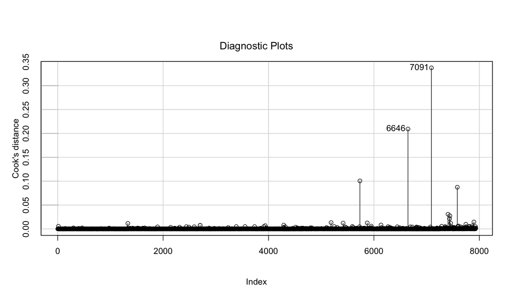

```r
influenceIndexPlot(glm_model_pca, vars = "C")
```

The Cook’s distance plot does not give an indication of influential points since all the points have less than 0.5 as the Cook’s distance.

### 3.2.5 Model improvement

To improve the Logistic regression model we can try the following approach: - **Adding Non-linear Terms**: Introduce polynomial terms (e.g., poly(PC3, 2), poly(PC4, 2)) or splines (e.g., using ns() or bs() from the splines package) for the significant PCs into your GLM formula.

We now use smooth functions (splines) to automatically model non-linearities by fitting a generalized additive model (GAM).

```r
gam_formula_str <- paste(
  "target ~",
  paste(paste0("s(", nonlinear_pcs, ")"), collapse = " + "),
  "+",
  paste(linear_pcs, collapse = " + ")
)
gam_formula <- as.formula(gam_formula_str)
print(paste("Using formula:", gam_formula_str))
```

```
## [1] "Using formula: target ~ s(PC1) + s(PC3) + s(PC4) + s(PC7) + s(PC8) + s(PC9) + s(PC11) + PC2 + PC5 + PC6 + PC10"
```

Now build the GAM model

```r
gam_model <- gam(gam_formula,
  data = train_data_final,
  family = binomial(link = "logit"),
  method = "REML"
)

summary(gam_model)
```

```
##
## Family: binomial
## Link function: logit
##
## Formula:
## target ~ s(PC1) + s(PC3) + s(PC4) + s(PC7) + s(PC8) + s(PC9) +
##     s(PC11) + PC2 + PC5 + PC6 + PC10
##
## Parametric coefficients:
##             Estimate Std. Error z value Pr(>|z|)
## (Intercept)  23.8752     2.2272  10.720  < 2e-16 ***
## PC2           7.9114     0.3837  20.619  < 2e-16 ***
## PC5          24.5373     4.7267   5.191 2.09e-07 ***
## PC6          -0.4701     0.4510  -1.042    0.297
## PC10         17.0858     1.9291   8.857  < 2e-16 ***
## ---
## Signif. codes:  0 '***' 0.001 '**' 0.01 '*' 0.05 '.' 0.1 ' ' 1
##
## Approximate significance of smooth terms:
##           edf Ref.df Chi.sq p-value
## s(PC1)  6.213  7.449 341.71  <2e-16 ***
## s(PC3)  7.745  8.526 203.29  <2e-16 ***
## s(PC4)  1.044  1.077 135.35  <2e-16 ***
## s(PC7)  6.756  7.928 117.14  <2e-16 ***
## s(PC8)  5.811  6.997  59.23  <2e-16 ***
## s(PC9)  6.720  7.913  62.91  <2e-16 ***
## s(PC11) 5.093  5.724 173.79  <2e-16 ***
## ---
## Signif. codes:  0 '***' 0.001 '**' 0.01 '*' 0.05 '.' 0.1 ' ' 1
##
## R-sq.(adj) =  0.431   Deviance explained = 36.2%
## -REML = 2878.2  Scale est. = 1         n = 6347
```

Plot of the splines effect:

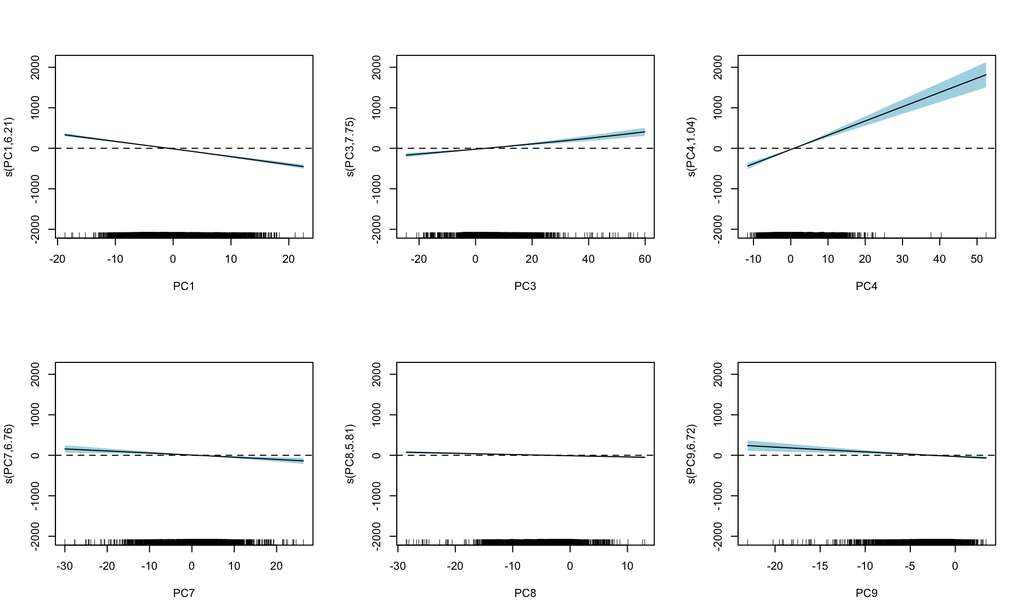

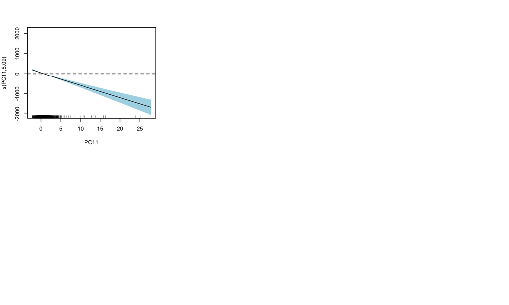

```r
par(mfrow = c(2, 3))
for (i in 1:11) {
  plot(gam_model, select = i, shade = TRUE, shade.col = "lightblue")
  abline(h = 0, lty = "dashed")
}
```

As we can see from the plots all the splines are significant. Now test the model on the test set.

```r
gam_probs <- predict(gam_model, newdata = test_data_final, type = "response")
gam_preds <- factor(ifelse(gam_probs > 0.5, positive_class, levels(train_data_final$target)[1]), levels = levels(test_data_final$target))
```

Confusion matrix

```r
cm_gam <- confusionMatrix(gam_preds, test_data_final$target, positive = positive_class)
cm_gam
```

```
## Confusion Matrix and Statistics
##
##                 Reference
## Prediction       candidate false_positive
##   candidate            799            595
##   false_positive         6            186
##
##                Accuracy : 0.6211
##                  95% CI : (0.5967, 0.645)
##     No Information Rate : 0.5076
##     P-Value [Acc > NIR] : < 2.2e-16
##
##                   Kappa : 0.2333
##
##  Mcnemar's Test P-Value : < 2.2e-16
##
##             Sensitivity : 0.2382
##             Specificity : 0.9925
##          Pos Pred Value : 0.9687
##          Neg Pred Value : 0.5732
##              Prevalence : 0.4924
##          Detection Rate : 0.1173
##    Detection Prevalence : 0.1211
##       Balanced Accuracy : 0.6154
##
##        'Positive' Class : false_positive
##
```

plot the confusion matrix. Let’s plot the confusion matrix.

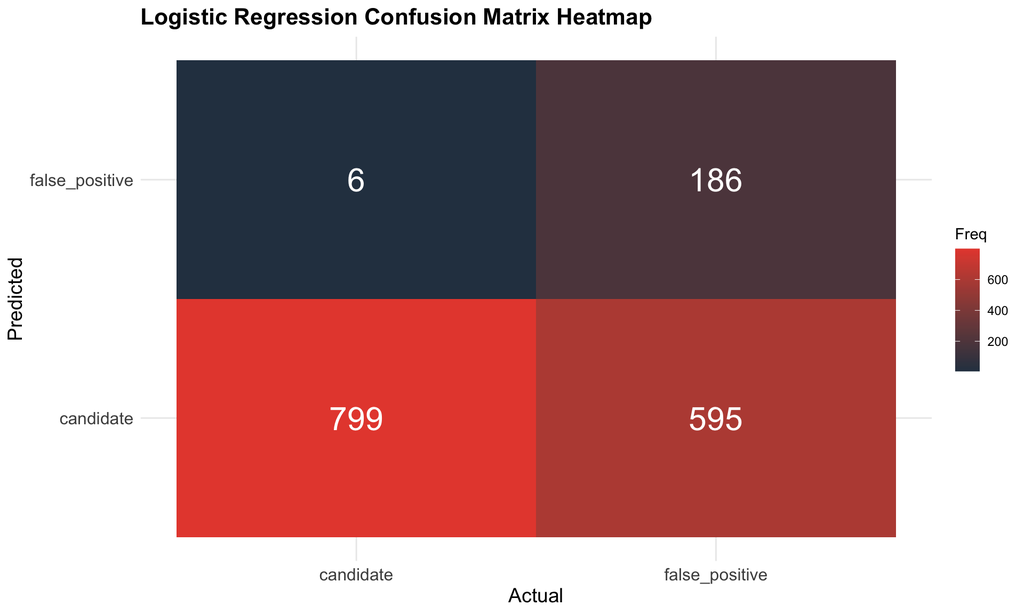

```r
cm_data <- as.data.frame(cm_gam$table)

# Create heatmap
ggplot(cm_data, aes(x = Reference, y = Prediction, fill = Freq)) +
  geom_tile() +
  geom_text(aes(label = Freq), color = "white", size = 8) +
  scale_fill_gradient(low = "#2C3E50", high = "#E74C3C") +
  theme_minimal() +
  labs(
    title = "Logistic Regression Confusion Matrix Heatmap",
    x = "Actual",
    y = "Predicted"
  ) +
  theme(
    axis.text = element_text(size = 12),
    axis.title = element_text(size = 14),
    plot.title = element_text(size = 16, face = "bold")
  )
```

ROC curve

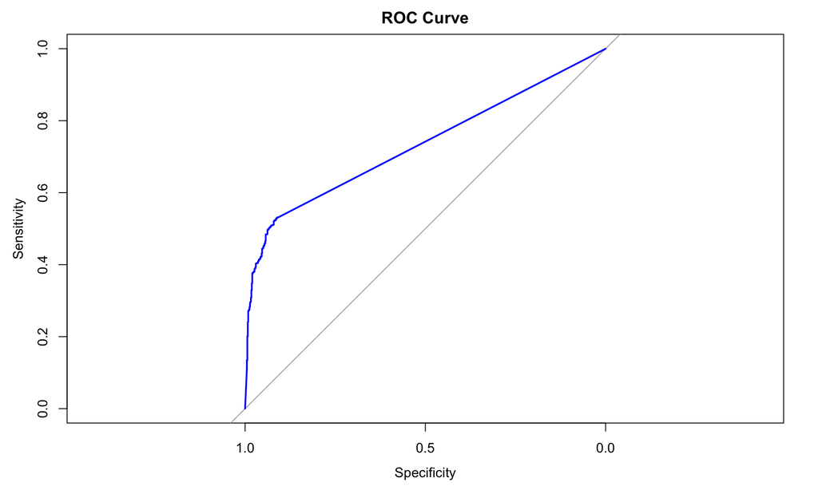

```r
# Create ROC curve
roc_curve_gam <- roc(test_data_final$target, gam_probs)
# Plot ROC curve
plot(roc_curve_gam, main = "ROC Curve", col = "blue", lwd = 2)
```

Residual analysis

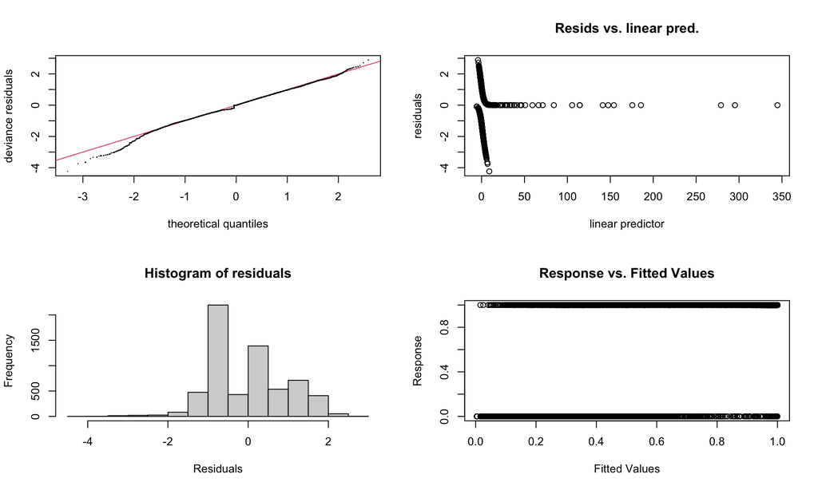

```
##
## Method: REML   Optimizer: outer newton
## full convergence after 9 iterations.
## Gradient range [-0.004233323,0.0005619485]
## (score 2878.224 & scale 1).
## Hessian positive definite, eigenvalue range [0.001996802,3.039552].
## Model rank =  68 / 68
##
## Basis dimension (k) checking results. Low p-value (k-index<1) may
## indicate that k is too low, especially if edf is close to k'.
##
##           k'  edf k-index p-value
## s(PC1)  9.00 6.21    0.97   0.005 **
## s(PC3)  9.00 7.75    0.99   0.190
## s(PC4)  9.00 1.04    0.99   0.325
## s(PC7)  9.00 6.76    0.98   0.115
## s(PC8)  9.00 5.81    0.99   0.230
## s(PC9)  9.00 6.72    1.00   0.530
## s(PC11) 9.00 5.09    0.99   0.295
## ---
## Signif. codes:  0 '***' 0.001 '**' 0.01 '*' 0.05 '.' 0.1 ' ' 1
```

```r
# GAM diagnostic plots
par(mfrow = c(2, 2))
gam.check(gam_model)
```

```r
par(mfrow = c(1, 1))
```

The improved model results in an increase of the specificity but a decrease of the sensitivity.

## 3.3 Save model performances

```r
# Create data frame with model performance metrics
models_performance_pca <- data.frame(
  Model = c("Random Forest PCA", "GLM PCA", "GAM PCA"),
  Accuracy = c(
    cm_rf$overall["Accuracy"],
    cm_glm_pca$overall["Accuracy"],
    cm_gam$overall["Accuracy"]
  ),
  Sensitivity = c(
    cm_rf$byClass["Sensitivity"],
    cm_glm_pca$byClass["Sensitivity"],
    cm_gam$byClass["Sensitivity"]
  ),
  Specificity = c(
    cm_rf$byClass["Specificity"],
    cm_glm_pca$byClass["Specificity"],
    cm_gam$byClass["Specificity"]
  ),
  AUC = c(
    auc(roc_curve_rf),
    auc(roc_curve_glm),
    auc(roc_curve_gam)
  )
)

# Round numeric columns to 4 decimal places
models_performance_pca[, 2:5] <- round(models_performance_pca[, 2:5], 4)

# Save the data frame to Rda
save(models_performance_pca, file = "data/Rdas/models_performance_pca.Rda")

# Display the results
models_performance_pca
```

| Model | Accuracy | Sensitivity | Specificity | AUC |
| --- | --- | --- | --- | --- |
| Random Forest PCA | 0.6267 | 0.9143 | 0.3303 | 0.6971 |
| GLM PCA | 0.7251 | 0.4635 | 0.9789 | 0.8690 |
| GAM PCA | 0.6211 | 0.2382 | 0.9925 | 0.7328 |